# State space SAM

alice carter

10/27/2021

### Building a state space stochastic antecedent model

Question: To what extent does ecosystem respiration in rivers retain memory of previous fluxes of primary productivity? In what types of rivers, or under what conditions do we observe more ecological memory? Over what time scale (days, weeks) does this memory occur?

Hypotheses: Rivers with higher fluxes of primary productivity will derive a greater portion of their respiration from autochthonous production, resulting in a possibility for ecological memory of productivity in respiration fluxes. Community dynamics will determine the likelihood of a time lag with phytoplankton dominated communities deriving most of their respiration from that days productivity and benthic, macrophyte dominated comunities demonstrating time lags in the response of ER to GPP.

Goals: 1. Take a simple SAM model of ER as a function of the previous five days of GPP and add observation error. 2. Test different time intervals of GPP memory 3. Run model on a set of autotrophic rivers from the Powell Center dataset.

## Model

Based on Ogle and Barber 2015, adapted from code by Bob Hall.

Model respiration ($R$) as a linear function of GPP on prior days:

$$R_t = b + a P^{ant}_t + \varepsilon_t$$

where $P_ant$ is a function of the previous j days of productivity (j = 0 is the current day)

$$P^{ant}_t = \displaystyle\sum_{j=0}^{J} w_j P_{t-j}$$

and process error is incorporated as:

$$\varepsilon_t \sim N (0, \sigma_{proc})$$

To make this a state space model, we model our observations of respiration, $R_{obs,t}$, as a function of the unobserved latent state, $R_t$.

$$R_{obs,t} \sim N (R_t, \sigma_{obs})$$

Priors are minimally informative, but a special prior on $w$, which is a simplex

$$w \sim dirichlet(1,1,...1)$$

### Stan Code

```r
sink("src/SAM/stan/SAM.stan")

cat("
    data {
      int <lower = 0> N;
      vector [N] P;
      vector [N] R;
      int <lower = 0> nweight;
      vector [nweight] alpha;
    }

    parameters {
      real a0;
      real <lower =0> a1;
      simplex [nweight] w;
      real <lower=0> sigma;
    }

    transformed parameters{
      vector  [N] Pant;
      Pant[1:5] = P[1:5];

      for (i in 6:N){
        vector  [nweight] Pvec;
        for(j in 1:nweight){
          Pvec[j]=w[j]*P[i-(j-1)];
        }
        Pant[i]=sum(Pvec);
      }
    }

    model {
      for (i in 6:N){
        R[i] ~ normal(a0 + a1*Pant[i], sigma); // likelihood
      }


    a0 ~ normal(0,5); //priors
    a1 ~ normal(0,1);
    w ~ dirichlet(alpha);
    sigma ~ normal(0,1) T[0,];
    }

    generated quantities{
      vector [N] R_hat;
      R_hat[1:5] = R[1:5];
      for(i in 6:N){
        R_hat[i] = normal_rng(a0 + a1 * Pant[i], sigma);
      }

    }" ,fill=TRUE)

sink()
```

### Simulate Data: Assign weight with 50% each on lags day 1 and 2

```r
# set parameters
a = 0.5
b = 0
w <- c(0.5,0.5,0,0,0)
sigma_proc = 0.2
sigma_obs = 0.2

# generate data
P <- numeric(100)
R <- numeric(100)
P[1] <- 10
for (i in 2:100)
  P[i] <- 1+0.9* P[i-1]+rnorm(1,0,0.85)

Pant <- numeric(100)
Pant[1:5]<-P[1:5]

for (i in 6:100){
  Pvec<-numeric(5)
  for(j in 1:5){
    Pvec[j]<-w[j]*P[i-(j-1)]
  }
  Pant[i]<-sum(Pvec)

}

R_mod <- 0.5 * P[1]
for (i in 2:100){
  R_mod[i] <- b + a*Pant[i] + rnorm(1, 0, sigma_proc)
}
for (i in 1:100){
  R[i] <- rnorm(1, R_mod[i], sigma_obs)
}
```

### Parameter recovery:

```r
fit_fake <- readRDS('src/SAM/stan/fits/fit_fake.rds')

print(fit_fake$fit, pars=c("a0", "a1", "w"))
```

```
## Inference for Stan model: SAM.
## 4 chains, each with iter=1000; warmup=500; thin=1;
## post-warmup draws per chain=500, total post-warmup draws=2000.
##
##       mean se_mean   sd  2.5%   25%   50%   75% 97.5% n_eff Rhat
## a0   -0.12    0.01 0.16 -0.43 -0.23 -0.12 -0.01  0.19   961    1
## a1    0.51    0.00 0.02  0.48  0.50  0.51  0.52  0.54   932    1
## w[1]  0.51    0.00 0.06  0.40  0.48  0.51  0.55  0.63  1785    1
## w[2]  0.41    0.00 0.06  0.28  0.37  0.41  0.45  0.53  1684    1
## w[3]  0.03    0.00 0.03  0.00  0.01  0.02  0.04  0.10  1515    1
## w[4]  0.02    0.00 0.02  0.00  0.01  0.02  0.03  0.07  1748    1
## w[5]  0.02    0.00 0.02  0.00  0.01  0.02  0.03  0.07  2176    1
##
## Samples were drawn using NUTS(diag_e) at Sun Nov 07 14:36:59 2021.
## For each parameter, n_eff is a crude measure of effective sample size,
## and Rhat is the potential scale reduction factor on split chains (at
## convergence, Rhat=1).
```

### Test model performance on real data

To see how well we are capturing the dynamics of a real system, we test the basic SAM model on real data from east canyon creek.

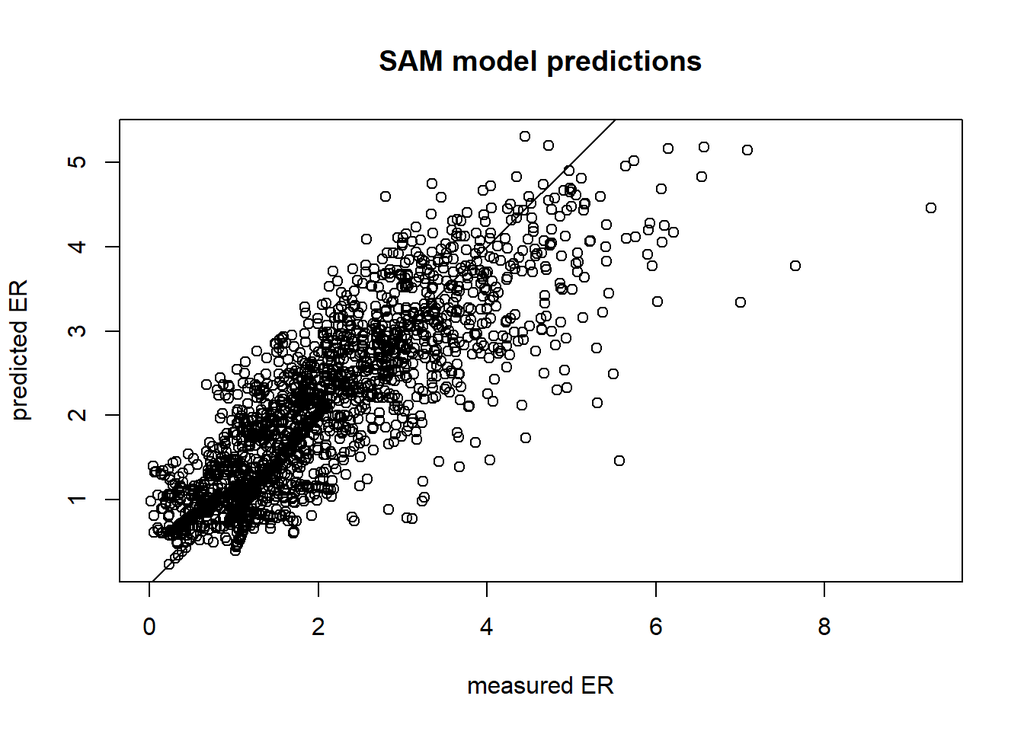

```r
east <- read_csv('data/east_metab.csv')
fit <- readRDS('src/SAM/stan/fits/east_sam_fit.rds')
R_hat <- summary(fit, pars = 'R_hat')$summary %>%
  as_tibble() %>%
  pull(mean)

# Do predictions correlate with data?
plot(-east$ER, R_hat, xlab = 'measured ER', ylab = 'predicted ER',
     main = 'SAM model predictions')
abline(0,1)
```

The predictions correlate reasonably well with the data, but we have not sufficiently captured the autocorrelation in respiration with this model.

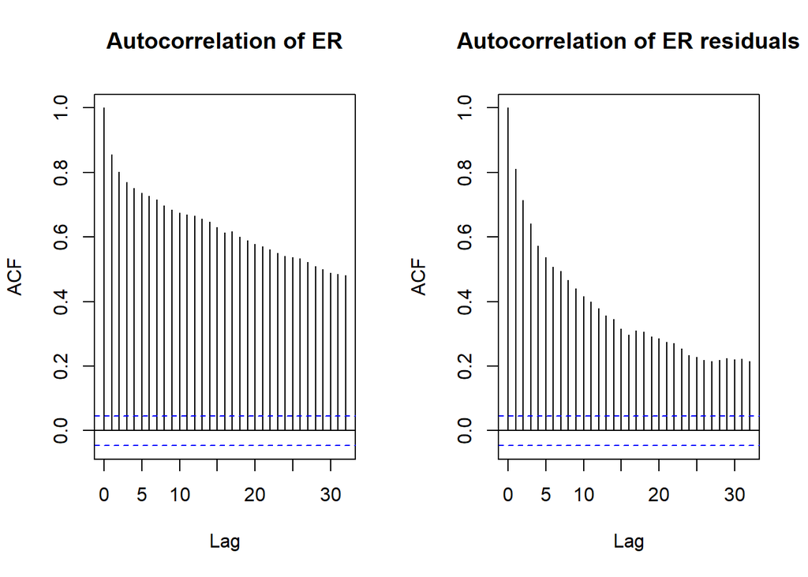

```r
# are we accounting for all of the autocorrelation in the respiration?
par(mfrow = c(1,2))
acf(-east$ER, main = 'Autocorrelation of ER')
acf(-east$ER - R_hat, main = 'Autocorrelation of ER residuals')
```

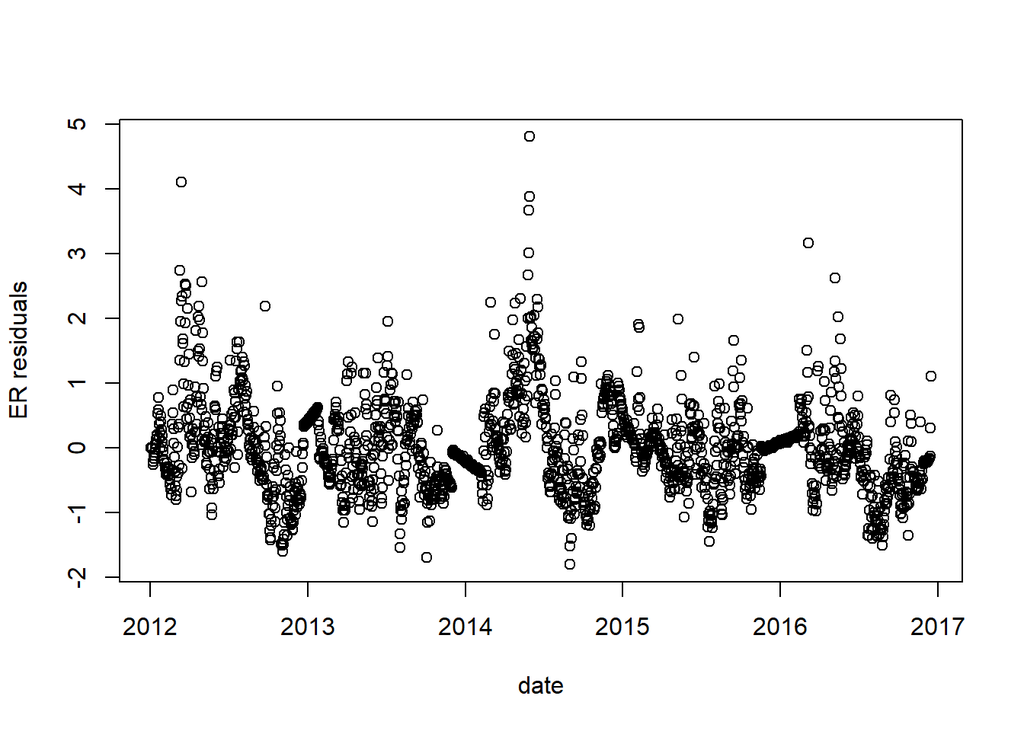

```r
# No and it looks like the pattern in the ER residuals might be seasonal
par(mfrow = c(1,1))
plot(east$Date, -east$ER-R_hat, xlab = 'date', ylab = 'ER residuals')
```

The residuals suggest the model is underestimating the impact of GPP on ER in the spring and overestimating it in the fall. This makes ecological sense and is a good argument for running this model seasonally

### Simple autoregressive model

Next, to compare to the results of the SAM model, I built a state space ar1 model of respiration.

Stan code:

```r
sink('src/SAM/stan/ar1_model.stan')
cat("
  data {
   int <lower = 0> N; // Sample size
   vector[N] R;
  }

  parameters {
   real a0; // Intercept
   real <lower = 0, upper = 1> a1;
   real <lower = 0> sigma_proc;
   real <lower = 0> sigma_obs;
   vector [N] mu;
  }

  model {
   mu[1] ~ normal(R[1], 0.01);
   mu[2:N] ~ normal(a0 + a1 * mu[1:(N-1)], sigma_proc);
   R ~ normal(mu, sigma_obs);


   a0 ~ normal(0,1);
   a1 ~ uniform(0,1);
   sigma_proc ~ normal(0,1) T[0,];
   sigma_obs ~ normal(0,1) T[0,];
  }

  generated quantities {
    vector [N] R_hat;
    vector [N] R_tilde;
    R_hat[1] = R[1];
    R_tilde[1] = R[1];
    for(i in 2:N){
        R_hat[i] = normal_rng(a0 + a1 * R_hat[i-1], sigma_proc);
        R_tilde[i] = normal_rng(R_hat[i], sigma_obs);
    }
  }", fill = T)


sink()
```

For this model, I am struggling to recover the parameters as well as for the SAM model. Using simulated data of a mean reverting random walk with 0.5 process error and o.2 observation error:

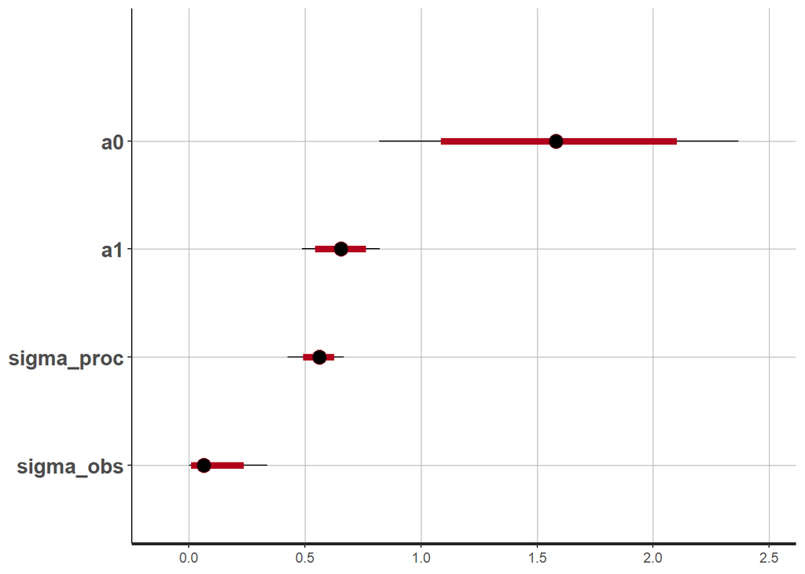

```r
a0 = 1 # intercept
a1 = 0.8 # ar1 coefficient
sigma_proc = 0.5
sigma_obs = 0.2

mu <- numeric(100)
mu[1] <- 5
R = mu[1] + rnorm(1, 0, sigma_obs)
for (i in 2:100){
  mu[i] <- a0 + a1 * mu[i-1] + rnorm(1, 0, sigma_proc)
  R[i] = mu[i] + rnorm(1, 0, 0.2)
}

fit <- readRDS('src/SAM/stan/fits/simulated_ar1_fit.rds')
plot(fit$fit, pars = c('a0', 'a1', 'sigma_proc', 'sigma_obs'))
```

This model tends to overestimate the intercept and have a large uncertainty surrounding that estimate. It also gives the following warnings from fitting: - divergent transitions - low bayesian fraction of missing information - largest Rhat is NA - low bulk effective sample size - low tail effective sample size

I am not sure how concerned I should be about these warnings, or if this recovery of parameters from simulated data is sufficient. It would be great to discuss.

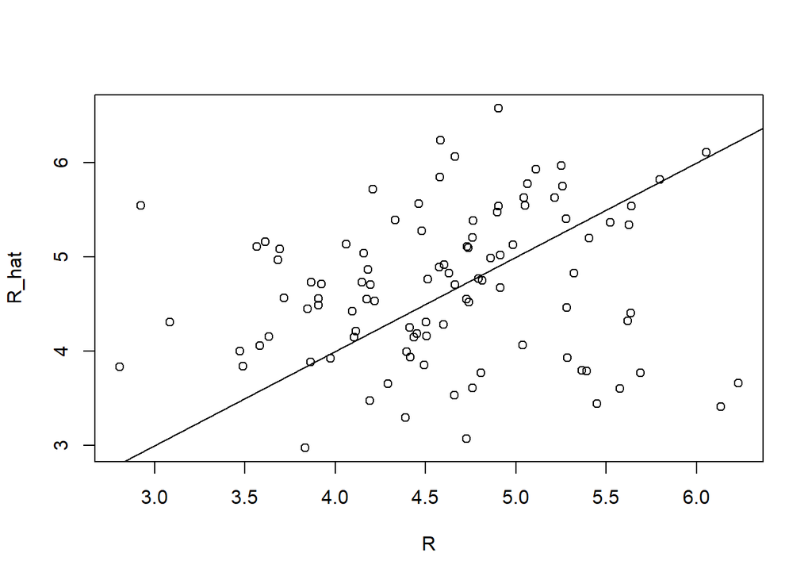

```r
R_hat <- summary(fit$fit, pars = 'R_hat')$summary %>%
  as_tibble() %>%
  pull(mean)
pp <- summary(fit$fit, pars = c('a0', 'a1', 'sigma_proc', 'sigma_obs'))$summary %>%
  as_tibble() %>%
  pull(mean)

mu <- numeric(100)
mu[1] <- 5
R_hat = mu[1] + rnorm(1, 0, pp[4])
for (i in 2:100){
  mu[i] <- pp[1] + pp[2] * mu[i-1] + rnorm(1, 0, pp[3])
  R_hat[i] = mu[i] + rnorm(1, 0, pp[4])
}
R <- fit$dat$R
plot(R, R_hat)
abline(0,1)
```

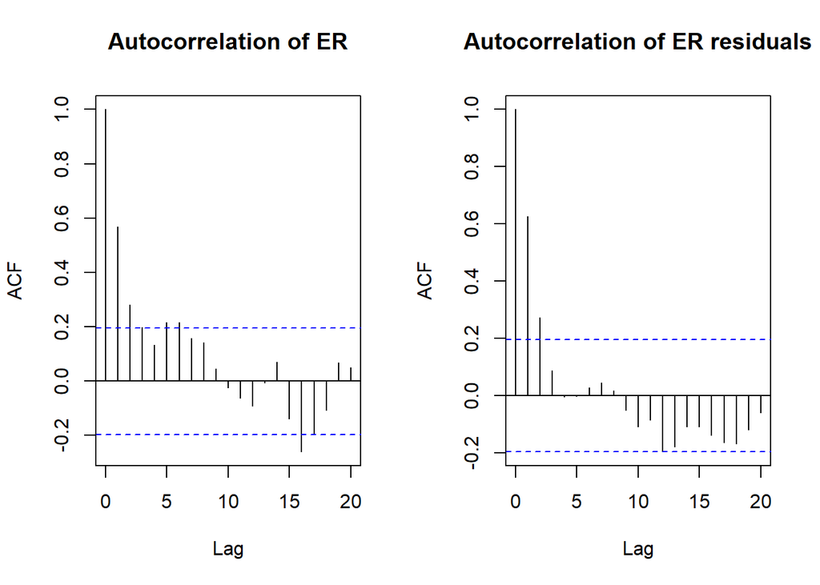

```r
par(mfrow = c(1,2))
acf(R, main = 'Autocorrelation of ER')
acf(R - R_hat, main = 'Autocorrelation of ER residuals')
```

In this case, the autocorrelation of the residuals is not accounted for in the model, but I don’t think it should be in a simple random walk model. Even in the parameters were recovered perfectly the autocorrelation of the estimates will be different than in the original data and will therefore still be present in the residuals. Next, I attempted to merge these two models and build a state space, ar1 model with GPP as an antecedent predictor. Below, I compare the results of running the East Canyon creek data in the basic SAM model, the ar1 model, and the combined model to see if we do any better at estimating ER.

### Model Comparison with real data

Stan code for combined SAM and ar1 model

```r
sink("src/SAM/stan/SAM_ar1.stan")

cat("

data {
 int <lower = 0> N;
 vector[N] R;
 vector [N] P;
 int <lower = 0> nweight;
 vector [nweight] alpha;
}

parameters {
 real a0; // Intercept
 real < lower = 0, upper = 1> a1;
 real <lower =0> a2;
 real < lower = 0 > sigma_obs;
 real < lower = 0 > sigma_proc;
 simplex [nweight] w;
 vector [N] mu;
}

transformed parameters{
 vector  [N] Pant;
 Pant[1:5] = P[1:5];

 for (i in 6:N){
   vector  [nweight] Pvec;
   for(j in 1:nweight){
     Pvec[j]=w[j]*P[i-(j-1)];
   }
   Pant[i]=sum(Pvec);
 }
}

model {
 mu[1:5] ~ normal(R[1:5], 0.01);
 for (i in 6:N){
  mu[i] ~ normal(a0 + a1 * mu[i-1] + a2*Pant[i], sigma_proc);
  R[i] ~ normal(mu[i], sigma_obs);
 }

 a0 ~ normal(0,5); //priors
 a1 ~ uniform(0,1);
 a2 ~ normal(0,1) T[0,];
 w ~ dirichlet(alpha);
 sigma_obs ~ normal(0,1) T[0,];
 sigma_proc ~ normal(0,1) T[0,];
}

generated quantities {
  vector [N] R_hat;
  R_hat[1:5] = R[1:5];
  for(i in 6:N){
    R_hat[i] = normal_rng(a0 + a1 * R_hat[i-1] + a2*Pant[i], sigma_proc);
  }

}", fill = T)
sink()
```

In the simulated data for this model, I set the parameters as follows:

$a_0 = 0$, intercept

$a_1 = 0.7$, autoregressive coefficient

$a_2 = 0.3$, antecedent model coefficient

$w <- c(0.5,0.5,0,0,0)$, weights on previous days

$\sigma_{proc} = 0.5$

$\sigma_{obs} = 0.2$

Again, I was able to recover the parameters, but with considerable uncertainty in the value of the intercept and in the weights on prior values of GPP.

Comparing the model performance across all three models on East Canyon Creek data:

### AR1 model

```r
fit_ar1 <- readRDS('src/SAM/stan/fits/east_ar1_fit.rds')
#plot(fit_ar1, pars = c('a0', 'a1', 'sigma_proc', 'sigma_obs'))
print(fit_ar1, pars = c('a0', 'a1', 'sigma_proc', 'sigma_obs'))
```

```
## Inference for Stan model: ar1_model.
## 4 chains, each with iter=1000; warmup=500; thin=1;
## post-warmup draws per chain=500, total post-warmup draws=2000.
##
##            mean se_mean   sd 2.5%  25%  50%  75% 97.5% n_eff Rhat
## a0         0.08       0 0.02 0.05 0.07 0.08 0.09  0.12   562 1.00
## a1         0.96       0 0.01 0.95 0.96 0.96 0.97  0.98   454 1.01
## sigma_proc 0.32       0 0.02 0.29 0.31 0.32 0.34  0.36   160 1.02
## sigma_obs  0.44       0 0.01 0.41 0.43 0.44 0.45  0.46   283 1.01
##
## Samples were drawn using NUTS(diag_e) at Sun Nov 07 17:12:52 2021.
## For each parameter, n_eff is a crude measure of effective sample size,
## and Rhat is the potential scale reduction factor on split chains (at
## convergence, Rhat=1).
```

```r
R_hat_ar1 <- summary(fit_ar1, pars = 'R_hat')$summary[,1]
```

where $a0$ is the intercept and $a1$ is the ar1 coefficient.

### Stochastic Antecedent Model

```r
fit_sam <- readRDS('src/SAM/stan/fits/east_sam_fit.rds')
#plot(fit_sam, pars = c('a0', 'a1', 'w'))
print(fit_sam, pars = c('a0', 'a1', 'w'))
```

```
## Inference for Stan model: SAM.
## 4 chains, each with iter=1000; warmup=500; thin=1;
## post-warmup draws per chain=500, total post-warmup draws=2000.
##
##      mean se_mean   sd 2.5%  25%  50%  75% 97.5% n_eff Rhat
## a0   0.19       0 0.04 0.12 0.17 0.19 0.22  0.26  1443    1
## a1   0.66       0 0.01 0.64 0.66 0.66 0.67  0.68  1392    1
## w[1] 0.89       0 0.03 0.83 0.87 0.89 0.91  0.94  1415    1
## w[2] 0.03       0 0.02 0.00 0.01 0.03 0.04  0.08  1943    1
## w[3] 0.03       0 0.02 0.00 0.01 0.03 0.04  0.08  1835    1
## w[4] 0.02       0 0.02 0.00 0.01 0.02 0.04  0.07  2090    1
## w[5] 0.02       0 0.02 0.00 0.01 0.02 0.03  0.06  2378    1
##
## Samples were drawn using NUTS(diag_e) at Thu Nov 04 11:54:43 2021.
## For each parameter, n_eff is a crude measure of effective sample size,
## and Rhat is the potential scale reduction factor on split chains (at
## convergence, Rhat=1).
```

```r
R_hat_sam <- summary(fit_sam, pars = 'R_hat')$summary[,1]
```

where $a0$ is the intercept, $a1$ is the coefficient on antecedent conditions in GPP, and $w$ are the weights on the current and preceding days GPP.

### Combined model

```r
fit_comb <- readRDS('src/SAM/stan/fits/east_combined_fit.rds')
#plot(fit_comb, pars = c('a0', 'a1', 'a2', 'w', 'sigma_proc', 'sigma_obs'))
print(fit_comb, pars = c('a0', 'a1', 'a2', 'w', 'sigma_proc', 'sigma_obs'))
```

```
## Inference for Stan model: SAM_ar1.
## 4 chains, each with iter=1000; warmup=500; thin=1;
## post-warmup draws per chain=500, total post-warmup draws=2000.
##
##             mean se_mean   sd  2.5%   25%   50%   75% 97.5% n_eff Rhat
## a0         -0.04       0 0.03 -0.09 -0.05 -0.04 -0.02  0.01   482 1.01
## a1          0.54       0 0.01  0.52  0.54  0.54  0.55  0.57   523 1.02
## a2          0.34       0 0.01  0.32  0.34  0.34  0.35  0.36   446 1.01
## w[1]        0.99       0 0.01  0.97  0.98  0.99  0.99  1.00   663 1.00
## w[2]        0.00       0 0.00  0.00  0.00  0.00  0.00  0.01   785 1.01
## w[3]        0.00       0 0.00  0.00  0.00  0.00  0.00  0.01   913 1.00
## w[4]        0.00       0 0.00  0.00  0.00  0.00  0.01  0.02  1045 1.00
## w[5]        0.00       0 0.01  0.00  0.00  0.00  0.01  0.02   743 1.01
## sigma_proc  0.52       0 0.01  0.51  0.52  0.52  0.53  0.54   247 1.04
## sigma_obs   0.05       0 0.02  0.03  0.03  0.04  0.06  0.09    10 1.82
##
## Samples were drawn using NUTS(diag_e) at Sun Nov 07 17:24:04 2021.
## For each parameter, n_eff is a crude measure of effective sample size,
## and Rhat is the potential scale reduction factor on split chains (at
## convergence, Rhat=1).
```

```r
R_hat_comb <- summary(fit_comb, pars = 'R_hat')$summary[,1]
```

where $a0$ is the intercept, $a1$ is the autoregressive coefficient, $a2$ is the coefficient on anteceded conditions in GPP, and $w$ are the weights on the current and preceding days GPP.

## East Canyon Creek

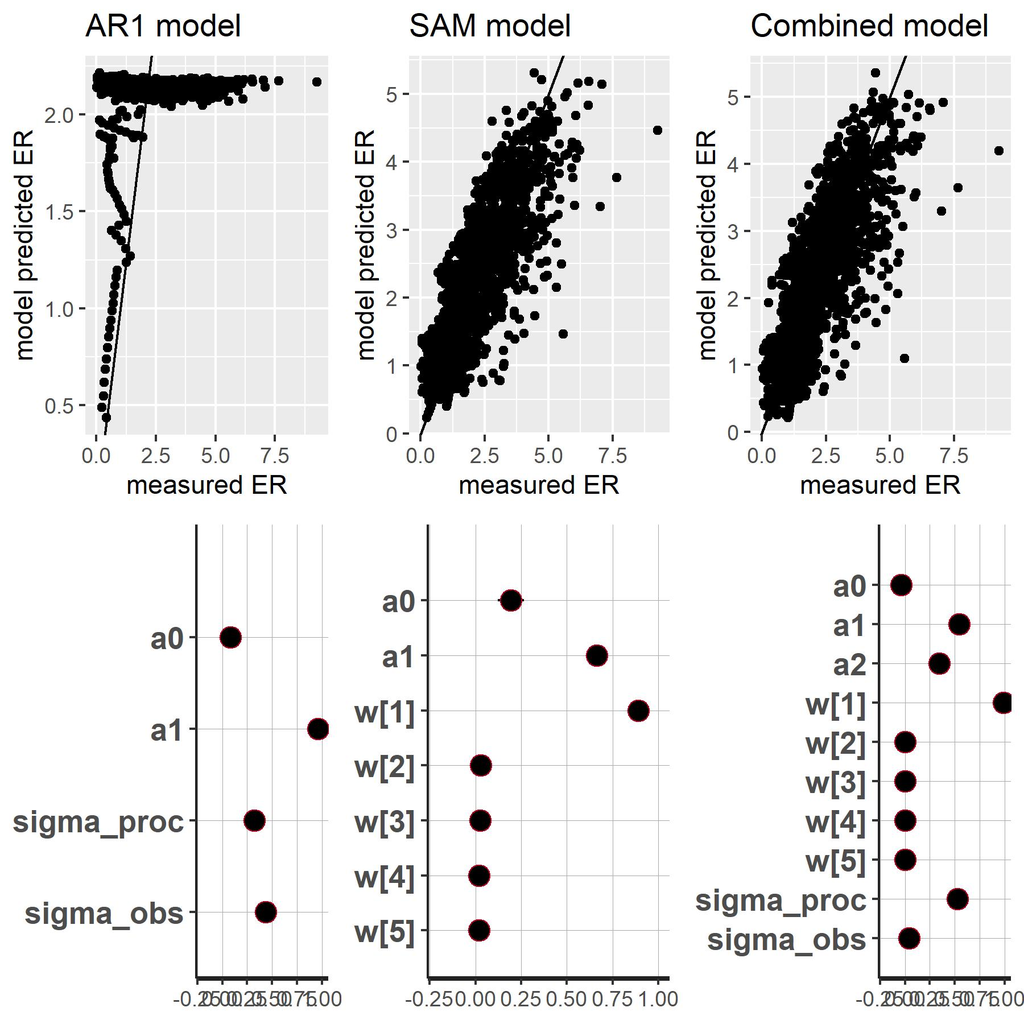

## Pecos River

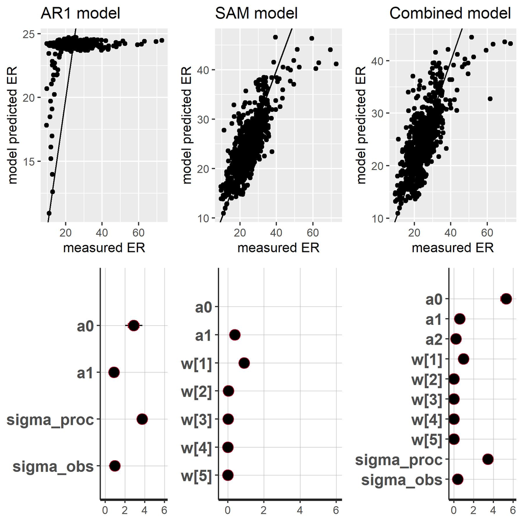

## Grand River

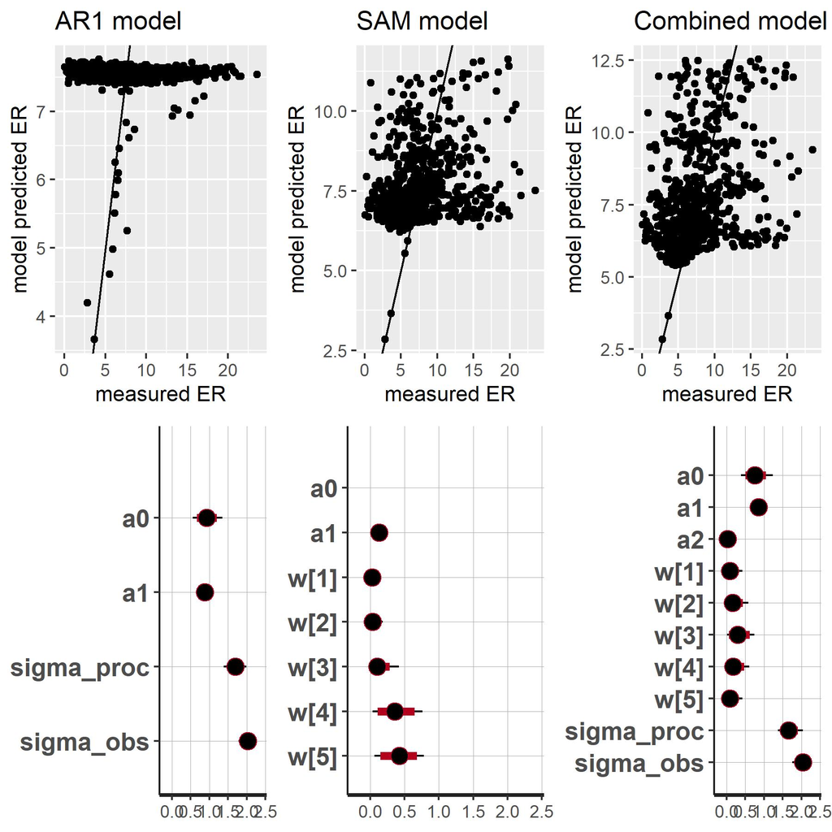

## Snake River

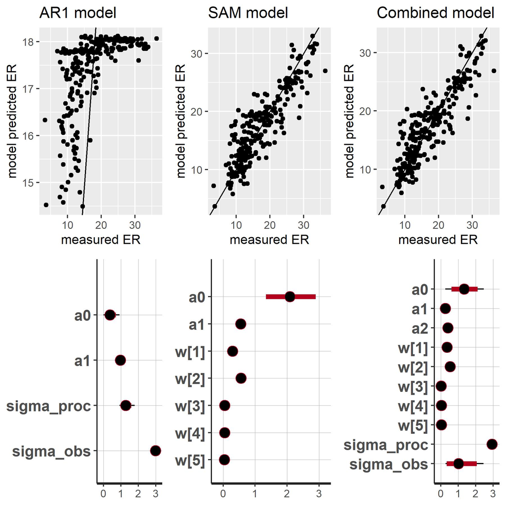

## Next:

1. Refine combined model
2. Model comparison
3. Constrain observation error